# profilepoint analysis Glaciolacustrine deposits

fabian gruber

October 24, 2017

How do those points that were classified correctly by the geologic map differ from those identified by the surveyors?

0 1 6 5 [1] “OBB error with all predictors of allpreds is 0.363636363636364” [1] “OBB error with all predictors of roughness is 0.272727272727273” [1] “OBB error with all predictors of localterrain is 0.454545454545455”

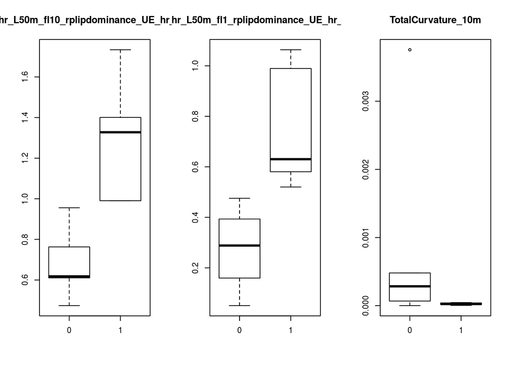

How about GLD and SB

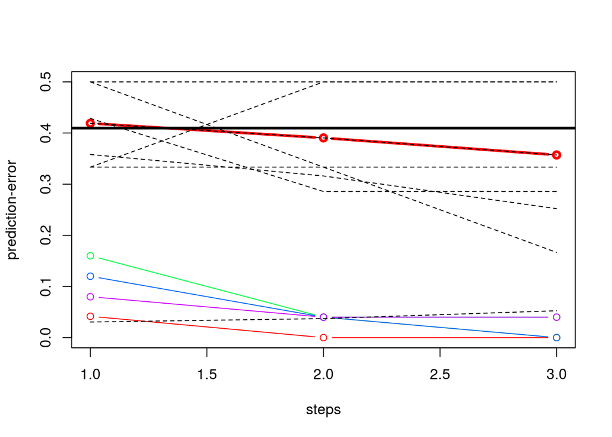

[1] “Prediction error at end is: 0.419047619047619” [2] “Prediction error at end is: 0.39047619047619” [3] “Prediction error at end is: 0.357142857142857”

| k 1 | k 2 | k 3 | k 4 | k 5 |
| --- | --- | --- | --- | --- |
| TRI_hr_ws44 | crosc_ws15_hr_hr | Channel_Network_Base_Level_50m | planc_DTM_50m_avg_ws3_50m | Total_Curvature_50m |
| longc_DTM_50m_avg_ws11_50m | minic_ws5_hr_hr | Maximal_Curvature_hr | fischerk_ws15_hr | crosc_ws15_hr_hr |
| profc_DTM_50m_avg_ws9_50m | geom_hr_L50m_fl1_rplippatchdensity_UE_hr_10cells_hr | maxic_ws7_10m | vectorstrength_hr_ws17_hr | Maximal_Curvature_hr |

[1] “OBB error with all predictors of allpreds is 0.225806451612903”

|  | GLD | SB | MeanDecreaseAccuracy | MeanDecreaseGini |
| --- | --- | --- | --- | --- |
| vectorruggedness_hr_ws55 | 0.0060381 | 0.0028517 | 0.0038389 | 0.2161616 |
| TRI_hr_ws45 | 0.0048071 | 0.0031548 | 0.0037201 | 0.1705919 |
| TRI_hr_ws48 | 0.0033333 | 0.0045857 | 0.0035335 | 0.1888936 |
| terraintexture_hr_ws37_tp25 | 0.0028667 | 0.0039349 | 0.0033915 | 0.1459834 |
| terraintexture_hr_ws49_tp25 | 0.0038095 | 0.0028849 | 0.0032483 | 0.1695211 |
| TRI_hr_ws44 | 0.0039333 | 0.0032024 | 0.0032098 | 0.0973897 |
| crosc_ws29_hr_hr | 0.0050000 | 0.0023325 | 0.0030962 | 0.2196322 |
| vectorruggedness_hr_ws59 | 0.0049714 | 0.0019683 | 0.0030381 | 0.1318008 |
| terraintexture_hr_ws53_tp25 | 0.0030000 | 0.0034190 | 0.0028182 | 0.2117407 |
| vectorruggedness_hr_ws45 | 0.0038333 | 0.0024167 | 0.0026844 | 0.1366598 |

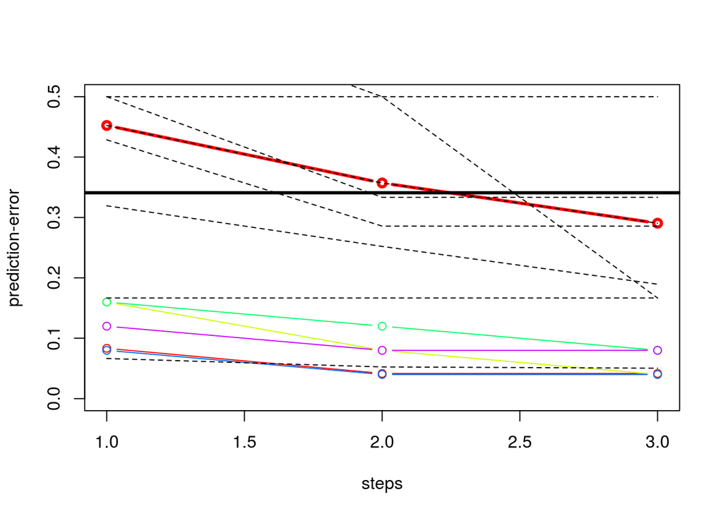

[1] “Prediction error at end is: 0.452380952380952” [2] “Prediction error at end is: 0.357142857142857” [3] “Prediction error at end is: 0.29047619047619”

| k 1 | k 2 | k 3 | k 4 | k 5 |
| --- | --- | --- | --- | --- |
| Texture_50m | Texture_50m | geom_hr_L3_fl1_rplipshannon_UE_hr_10cells_hr | vectorruggedness_hr_ws51 | dtm_hr_TEXTURE_r5 |
| TRI_hr_ws52 | vectorruggedness_hr_ws53 | TRI_hr_ws47 | terraintexture_hr_ws21_tp25 | geom_hr_L3_fl1_rplipdominance_UE_hr_20cells_hr |
| TRI_hr_ws51 | vectorstrength_hr_ws19_hr | geom_hr_L3_fl1_rplippatchdensity_UE_hr_60cells_hr | geom_hr_L3_fl10_rplipsimpson_UE_hr_20cells_hr | vectorstrength_hr_ws15_hr |

[1] “OBB error with all predictors of roughness is 0.258064516129032”

|  | GLD | SB | MeanDecreaseAccuracy | MeanDecreaseGini |
| --- | --- | --- | --- | --- |
| TRI_hr_ws44 | 0.0088333 | 0.0087611 | 0.0087318 | 0.2683297 |
| vectorruggedness_hr_ws53 | 0.0067333 | 0.0056603 | 0.0056053 | 0.2405195 |
| vectorruggedness_hr_ws41 | 0.0075333 | 0.0044950 | 0.0052505 | 0.3556761 |
| terraintexture_hr_ws57_tp25 | 0.0042000 | 0.0050825 | 0.0047394 | 0.1705088 |
| TRI_hr_ws43 | 0.0048333 | 0.0043468 | 0.0042633 | 0.2150839 |
| terraintexture_hr_ws53_tp25 | 0.0069333 | 0.0034524 | 0.0042038 | 0.2879150 |
| vectorruggedness_hr_ws49 | 0.0051667 | 0.0037476 | 0.0040569 | 0.2393922 |
| TRI_hr_ws49 | 0.0064000 | 0.0048556 | 0.0039886 | 0.2169068 |
| vectorruggedness_hr_ws5 | 0.0059667 | 0.0031381 | 0.0038148 | 0.1827614 |
| TRI_hr_ws46 | 0.0043000 | 0.0035333 | 0.0036392 | 0.1777847 |

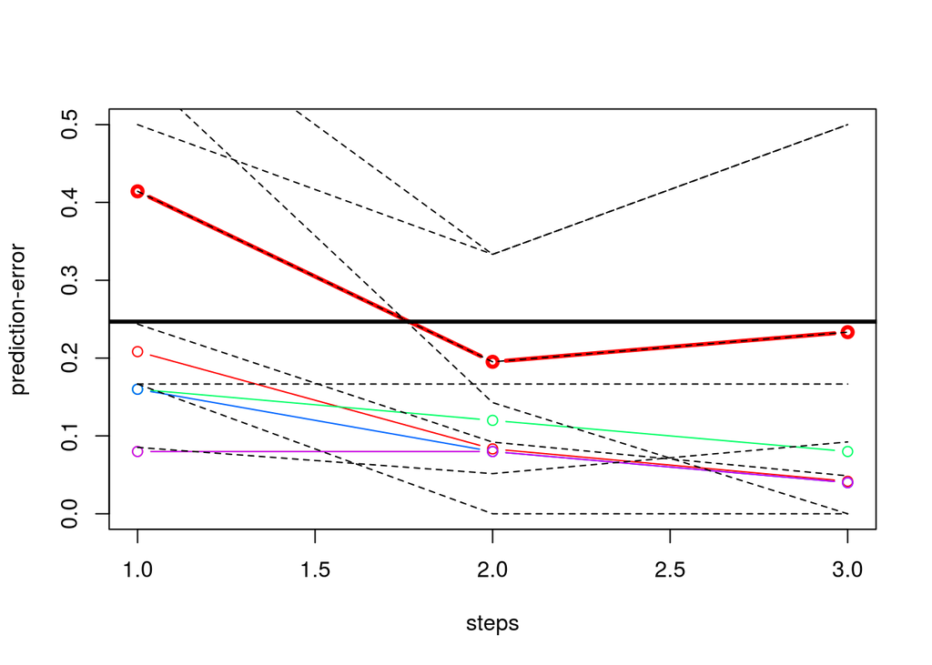

[1] “Prediction error at end is: 0.414285714285714” [2] “Prediction error at end is: 0.195238095238095” [3] “Prediction error at end is: 0.233333333333333”

| k 1 | k 2 | k 3 | k 4 | k 5 |
| --- | --- | --- | --- | --- |
| Maximal_Curvature_50m | Tangential_Curvature_50m | crosc_ws15_10m | TangentialCurvature_10m | crosc_ws15_hr_hr |
| longc_ws3_hr_hr | planc_DTM_50m_avg_ws3_50m | profc_ws3_hr_hr | profc_ws3_hr_hr | CrossSectionalCurvature_hr |
| CrossSectionalCurvature_hr | maxic_DTM_50m_avg_ws9_50m | Convergence_Index_50m | Convergence_Index_hr | dtm_hr_CONVEX_r10 |

[1] “OBB error with all predictors of localterrain is 0.354838709677419”

|  | GLD | SB | MeanDecreaseAccuracy | MeanDecreaseGini |
| --- | --- | --- | --- | --- |
| Total_Curvature_50m | 0.0113500 | 0.0057817 | 0.0075538 | 0.4915472 |
| Total_Curvature_hr | 0.0078905 | 0.0046548 | 0.0058892 | 0.3144783 |
| crosc_ws5_10m | 0.0087000 | 0.0046762 | 0.0058678 | 0.2415026 |
| crosc_ws29_hr_hr | 0.0100333 | 0.0041286 | 0.0056480 | 0.2786038 |
| slope_DTM_50m_avg_ws9_50m | 0.0030619 | 0.0056374 | 0.0046714 | 0.3061768 |
| maxic_ws15_10m | 0.0035381 | 0.0046365 | 0.0041468 | 0.1488047 |
| slope_DTM_50m_avg_ws7_50m | 0.0069667 | 0.0030929 | 0.0041422 | 0.2883760 |
| crosc_ws15_10m | 0.0076333 | 0.0025556 | 0.0040357 | 0.3401486 |
| slope_DTM_50m_avg_ws11_50m | 0.0063690 | 0.0025792 | 0.0035815 | 0.3245841 |
| planc_ws11_10m | 0.0047667 | 0.0027937 | 0.0033080 | 0.2046512 |

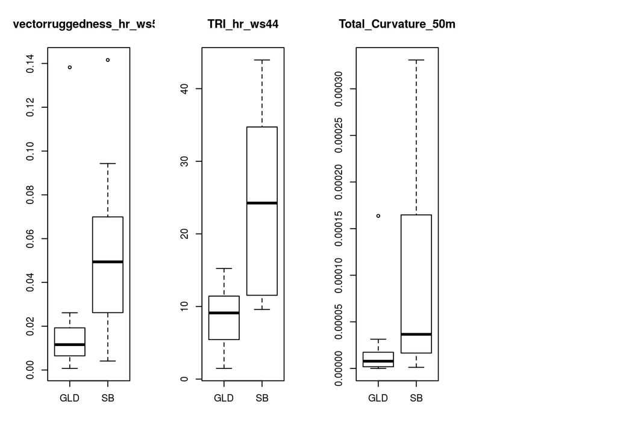

How does this compare to the differences between the units on the geological map?

[1] “OBB error with all predictors of allpreds is 0.0204798127559977”

|  | GLD | SB | MeanDecreaseAccuracy | MeanDecreaseGini |
| --- | --- | --- | --- | --- |
| elev_ws3_10m | 0.0967551 | 0.0163948 | 0.0291266 | 35.724749 |
| Channel_Network_Base_Level_hr | 0.0814378 | 0.0120471 | 0.0230059 | 24.471193 |
| elev_ws15_10m | 0.0828575 | 0.0109695 | 0.0224043 | 25.227966 |
| elev_ws5_10m | 0.0747086 | 0.0119014 | 0.0217830 | 26.371283 |
| elev_ws11_10m | 0.0756549 | 0.0113837 | 0.0214982 | 24.547934 |
| ChannelNetworkBaseLevel_10m | 0.0562802 | 0.0055380 | 0.0135646 | 16.438802 |
| slope_DTM_50m_avg_ws11_50m | 0.0369358 | 0.0036637 | 0.0089265 | 6.033743 |
| Relative_Slope_Position_50m | 0.0292755 | 0.0048486 | 0.0087269 | 14.697314 |
| slope_DTM_50m_avg_ws9_50m | 0.0322532 | 0.0038624 | 0.0083578 | 7.800692 |
| Vertical_Distance_to_Channel_Network_50m | 0.0355080 | 0.0029034 | 0.0080426 | 14.264978 |

[1] “OBB error with all predictors of roughness is 0.0965476887068461”

|  | GLD | SB | MeanDecreaseAccuracy | MeanDecreaseGini |
| --- | --- | --- | --- | --- |
| TRI_hr_ws49 | 0.0087984 | 0.0127314 | 0.0121053 | 3.939358 |
| TRI_hr_ws50 | 0.0093739 | 0.0120094 | 0.0115802 | 4.025250 |
| TRI_hr_ws48 | 0.0070737 | 0.0101879 | 0.0096597 | 3.364503 |
| TRI_hr_ws47 | 0.0073162 | 0.0088924 | 0.0086366 | 3.334750 |
| TRI_hr_ws46 | 0.0050716 | 0.0076461 | 0.0072233 | 2.564999 |
| TRI_hr_ws40 | 0.0033536 | 0.0077469 | 0.0070452 | 2.249283 |
| TRI_hr_ws43 | 0.0043873 | 0.0073355 | 0.0068614 | 2.399785 |
| TRI_hr_ws45 | 0.0032983 | 0.0074173 | 0.0067464 | 2.456853 |
| TRI_hr_ws44 | 0.0039718 | 0.0071839 | 0.0066606 | 2.136046 |
| TRI_hr_ws42 | 0.0049991 | 0.0068669 | 0.0065940 | 2.446349 |

[1] “OBB error with all predictors of localterrain is 0.114552893045003”

|  | GLD | SB | MeanDecreaseAccuracy | MeanDecreaseGini |
| --- | --- | --- | --- | --- |
| slope_DTM_50m_avg_ws11_50m | 0.0411006 | 0.0106576 | 0.0154250 | 15.111209 |
| slope_DTM_50m_avg_ws9_50m | 0.0307180 | 0.0118362 | 0.0148174 | 12.133873 |
| slope_DTM_50m_avg_ws7_50m | 0.0138308 | 0.0104683 | 0.0110132 | 7.555791 |
| slope_DTM_50m_avg_ws5_50m | 0.0083429 | 0.0104895 | 0.0101512 | 6.674218 |
| slope_ws15_10m | 0.0024036 | 0.0093332 | 0.0082327 | 4.862575 |
| maxic_DTM_50m_avg_ws11_50m | 0.0184532 | 0.0057777 | 0.0077761 | 8.785738 |
| slope_DTM_50m_avg_ws3_50m | 0.0026986 | 0.0082424 | 0.0073614 | 5.004225 |
| Convexity_50m | 0.0155902 | 0.0052981 | 0.0069283 | 13.732615 |
| slope_ws11_10m | 0.0030564 | 0.0070698 | 0.0064316 | 5.051733 |
| Slope_10m | -0.0018686 | 0.0070794 | 0.0056419 | 3.750223 |

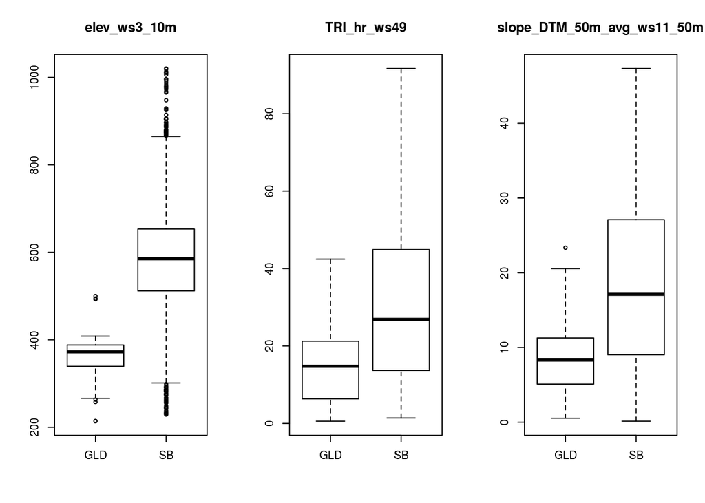

How about GLD and TG

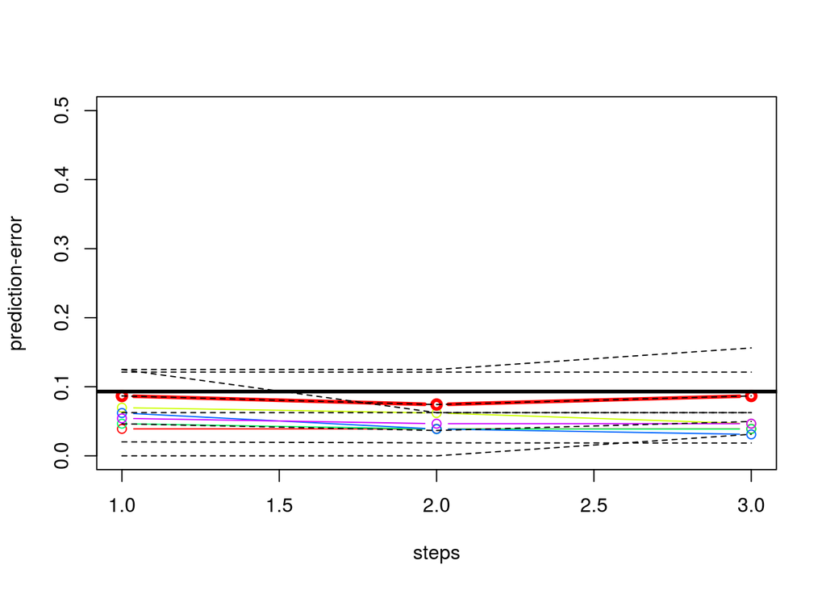

[1] “Prediction error at end is: 0.0867424242424242” [2] “Prediction error at end is: 0.0742424242424242” [3] “Prediction error at end is: 0.0867424242424242”

| k 1 | k 2 | k 3 | k 4 | k 5 |
| --- | --- | --- | --- | --- |
| geom_hr_L50m_fl1_rpliprichness_UE_hr_40cells_hr | geom_hr_L50m_fl1_rpliprichness_UE_hr_40cells_hr | geom_hr_L50m_fl10_rpliprichness_UE_hr_20cells_hr | Channel_Network_Base_Level_50m | geom_hr_L50m_fl1_rpliprichness_UE_hr_40cells_hr |
| geom_hr_L3_fl1_rplipmps_UE_hr_20cells_hr | elev_ws3_10m | longc_ws3_hr_hr | elev_ws5_10m | planc_DTM_50m_avg_ws11_50m |
| geom_hr_L3_fl1_rplipedgedensity_UE_hr_10cells_hr | VerticalDistancetoChannelNetwork_10m | longc_ws11_10m | Maximal_Curvature_50m | profc_DTM_50m_avg_ws11_50m |

[1] “OBB error with all predictors of allpreds is 0.0683229813664596”

|  | GLD | TG | MeanDecreaseAccuracy | MeanDecreaseGini |
| --- | --- | --- | --- | --- |
| elev_ws3_10m | 0.0122500 | 0.0004652 | 0.0011264 | 0.4406515 |
| geom_hr_L3_fl1_rplipdominance_UE_hr_60cells_hr | 0.0076381 | 0.0005782 | 0.0010630 | 0.2577053 |
| Channel_Network_Base_Level_hr | 0.0048714 | 0.0006817 | 0.0009931 | 0.3773677 |
| Slope_50m | 0.0045667 | 0.0007065 | 0.0009860 | 0.2299249 |
| elev_ws5_10m | 0.0096524 | 0.0004266 | 0.0009380 | 0.4652158 |
| elev_ws11_10m | 0.0070381 | 0.0004656 | 0.0009347 | 0.4462526 |
| maxic_DTM_50m_avg_ws3_50m | 0.0080413 | 0.0004084 | 0.0008942 | 0.3313081 |
| maxic_DTM_50m_avg_ws7_50m | 0.0070667 | 0.0004354 | 0.0008429 | 0.2890405 |
| elev_ws15_10m | 0.0069333 | 0.0003619 | 0.0008215 | 0.4091094 |
| Slope_Height_hr | 0.0005667 | 0.0008381 | 0.0007840 | 0.3226855 |

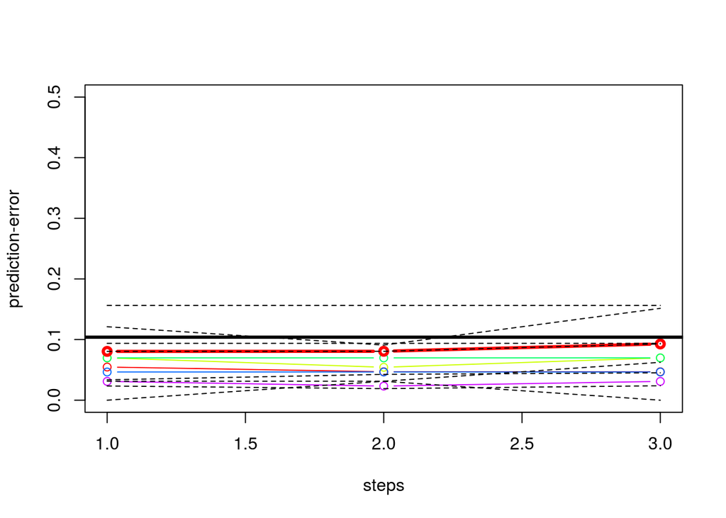

[1] “Prediction error at end is: 0.0804924242424242” [2] “Prediction error at end is: 0.0806818181818182” [3] “Prediction error at end is: 0.0928030303030303”

| k 1 | k 2 | k 3 | k 4 | k 5 |
| --- | --- | --- | --- | --- |
| geom_hr_L3_fl10_rplipedgedensity_UE_hr_10cells_hr | geom_hr_L50m_fl10_rpliprichness_UE_hr_20cells_hr | geom_hr_L50m_fl1_rpliprichness_UE_hr_40cells_hr | geom_hr_L50m_fl1_rplipedgedensity_UE_hr_10cells_hr | geom_hr_L50m_fl1_rpliprichness_UE_hr_40cells_hr |
| fischerk_ws55_hr | geom_hr_L50m_fl10_rplipdominance_UE_hr_40cells_hr | geom_hr_L50m_fl10_rplipdominance_UE_hr_60cells_hr | geom_hr_L50m_fl1_rplipshape_UE_hr_10cells_hr | vectorstrength_hr_ws9_hr |
| vectorstrength_hr_ws55_hr | geom_hr_L50m_fl1_rplipmps_UE_hr_10cells_hr | terraintexture_hr_ws29_tp5 | geom_hr_L3_fl10_rplipmps_UE_hr_10cells_hr | TRI_hr_ws38 |

[1] “OBB error with all predictors of roughness is 0.0683229813664596”

|  | GLD | TG | MeanDecreaseAccuracy | MeanDecreaseGini |
| --- | --- | --- | --- | --- |
| terraintexture_hr_ws37_tp25 | 0.0016000 | 0.0015836 | 0.0015011 | 0.0245259 |
| geom_hr_L50m_fl1_rplippatchdensity_UE_hr_40cells_hr | -0.0015667 | 0.0014768 | 0.0013067 | 0.0938502 |
| fischerk_ws9_hr | -0.0005000 | 0.0013998 | 0.0012588 | 0.0678669 |
| vectorstrength_hr_ws11_hr | 0.0003048 | 0.0012446 | 0.0012263 | 0.0375202 |
| vectorstrength_hr_ws49_hr | -0.0002333 | 0.0012184 | 0.0011016 | 0.0453689 |
| vectorstrength_hr_ws59_hr | 0.0005000 | 0.0010603 | 0.0009993 | 0.1025367 |
| dtm_hr_TEXTURE_r10 | 0.0003333 | 0.0009930 | 0.0009633 | 0.2055344 |
| geom_hr_L3_fl1_rplipshannon_UE_hr_20cells_hr | 0.0006000 | 0.0010145 | 0.0009558 | 0.1489583 |
| vectorstrength_hr_ws53_hr | -0.0001143 | 0.0010256 | 0.0009350 | 0.0436714 |
| fischerk_ws19_hr | -0.0005000 | 0.0009818 | 0.0008769 | 0.1090894 |

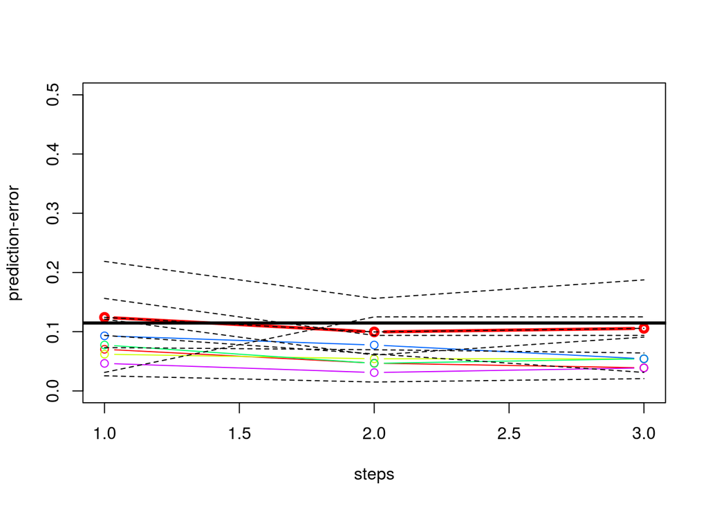

[1] “Prediction error at end is: 0.124242424242424” [2] “Prediction error at end is: 0.0996212121212121” [3] “Prediction error at end is: 0.105681818181818”

| k 1 | k 2 | k 3 | k 4 | k 5 |
| --- | --- | --- | --- | --- |
| crosc_ws11_10m | dtm_hr_CONVEX_r5 | planc_DTM_50m_avg_ws11_50m | Convexity_10m | longc_DTM_50m_avg_ws3_50m |
| maxic_DTM_50m_avg_ws7_50m | planc_DTM_50m_avg_ws5_50m | maxic_DTM_50m_avg_ws3_50m | slope_ws5_hr_hr | longc_ws3_hr_hr |
| profc_DTM_50m_avg_ws11_50m | longc_DTM_50m_avg_ws3_50m | maxic_DTM_50m_avg_ws7_50m | Maximal_Curvature_50m | profc_DTM_50m_avg_ws3_50m |

[1] “OBB error with all predictors of localterrain is 0.062111801242236”

|  | GLD | TG | MeanDecreaseAccuracy | MeanDecreaseGini |
| --- | --- | --- | --- | --- |
| profc_ws13_hr_hr | -0.0017667 | 0.0025030 | 0.0022877 | 0.1138785 |
| longc_DTM_50m_avg_ws11_50m | 0.0056190 | 0.0019465 | 0.0022462 | 0.3648176 |
| profc_DTM_50m_avg_ws11_50m | 0.0166857 | 0.0015237 | 0.0022195 | 0.5078849 |
| Maximal_Curvature_50m | 0.0050524 | 0.0019378 | 0.0021068 | 0.4201130 |
| profc_ws19_hr_hr | -0.0019667 | 0.0022799 | 0.0019469 | 0.1116327 |
| profc_ws15_hr_hr | -0.0008667 | 0.0020840 | 0.0019164 | 0.1238939 |
| maxic_DTM_50m_avg_ws3_50m | 0.0029048 | 0.0015088 | 0.0017247 | 0.5693712 |
| slope_ws13_hr_hr | -0.0003000 | 0.0016337 | 0.0016812 | 0.3026946 |
| profc_DTM_50m_avg_ws9_50m | 0.0037000 | 0.0015487 | 0.0016593 | 0.2295097 |
| planc_DTM_50m_avg_ws5_50m | 0.0039333 | 0.0015074 | 0.0015833 | 0.2016608 |

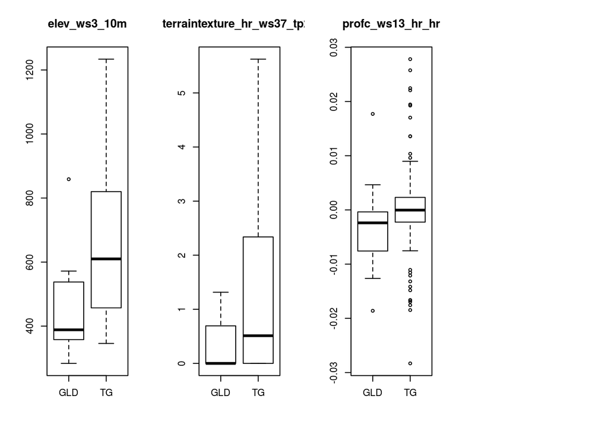

How does this compare to the differences between the units on the geological map?

[1] “OBB error with all predictors of allpreds is 0.0247668060469604”

|  | GLD | TG | MeanDecreaseAccuracy | MeanDecreaseGini |
| --- | --- | --- | --- | --- |
| elev_ws11_10m | 0.0928890 | 0.0067490 | 0.0141979 | 32.76398 |
| elev_ws5_10m | 0.0783598 | 0.0059708 | 0.0123002 | 26.17145 |
| elev_ws3_10m | 0.0787063 | 0.0055509 | 0.0119155 | 26.97630 |
| elev_ws15_10m | 0.0666417 | 0.0060938 | 0.0113975 | 22.44579 |
| Channel_Network_Base_Level_hr | 0.0598195 | 0.0037647 | 0.0086783 | 22.37182 |
| Relative_Slope_Position_50m | 0.0510857 | 0.0043024 | 0.0083568 | 14.24593 |
| Channel_Network_Base_Level_50m | 0.0499942 | 0.0040502 | 0.0080067 | 13.93923 |
| ChannelNetworkBaseLevel_10m | 0.0599108 | 0.0013578 | 0.0064306 | 21.19846 |
| Texture_50m | 0.0421761 | 0.0012830 | 0.0048381 | 13.82203 |
| Vertical_Distance_to_Channel_Network_50m | 0.0170721 | 0.0028274 | 0.0040586 | 6.94525 |

[1] “OBB error with all predictors of roughness is 0.0807073954983923”

|  | GLD | TG | MeanDecreaseAccuracy | MeanDecreaseGini |
| --- | --- | --- | --- | --- |
| vectorruggedness_hr_ws53 | -0.0019804 | 0.0100388 | 0.0089996 | 3.561337 |
| vectorruggedness_hr_ws47 | -0.0028268 | 0.0096063 | 0.0085436 | 3.185602 |
| vectorruggedness_hr_ws51 | -0.0009730 | 0.0093458 | 0.0084506 | 4.091794 |
| vectorruggedness_hr_ws45 | -0.0005740 | 0.0091478 | 0.0083024 | 3.204147 |
| vectorruggedness_hr_ws57 | -0.0021131 | 0.0086933 | 0.0077516 | 4.152584 |
| vectorruggedness_hr_ws55 | -0.0012012 | 0.0085799 | 0.0077137 | 4.230028 |
| vectorruggedness_hr_ws49 | -0.0007478 | 0.0082647 | 0.0074761 | 3.129565 |
| vectorruggedness_hr_ws59 | -0.0009667 | 0.0080905 | 0.0072958 | 4.175532 |
| Texture_50m | 0.0417937 | 0.0034529 | 0.0068256 | 21.212626 |
| vectorruggedness_hr_ws43 | -0.0029985 | 0.0077602 | 0.0068129 | 3.246143 |

[1] “OBB error with all predictors of localterrain is 0.0839228295819936”

|  | GLD | TG | MeanDecreaseAccuracy | MeanDecreaseGini |
| --- | --- | --- | --- | --- |
| slope_ws13_hr_hr | -0.0007035 | 0.0067014 | 0.0060578 | 4.785466 |
| slope_ws3_10m | -0.0007270 | 0.0058580 | 0.0052849 | 4.423250 |
| slope_ws5_hr_hr | 0.0031907 | 0.0052987 | 0.0051217 | 6.793899 |
| slope_DTM_50m_avg_ws11_50m | -0.0001361 | 0.0056107 | 0.0051031 | 8.380607 |
| slope_ws11_hr_hr | 0.0004023 | 0.0054501 | 0.0049906 | 3.910132 |
| Slope_10m | 0.0005226 | 0.0051306 | 0.0047310 | 5.303030 |
| slope_ws19_hr_hr | 0.0013485 | 0.0048707 | 0.0045672 | 4.061056 |
| slope_ws5_10m | 0.0000810 | 0.0047695 | 0.0043601 | 4.335344 |
| slope_DTM_50m_avg_ws9_50m | -0.0005464 | 0.0046311 | 0.0041749 | 7.287516 |
| planc_ws15_hr_hr | -0.0026221 | 0.0047998 | 0.0041520 | 1.904092 |

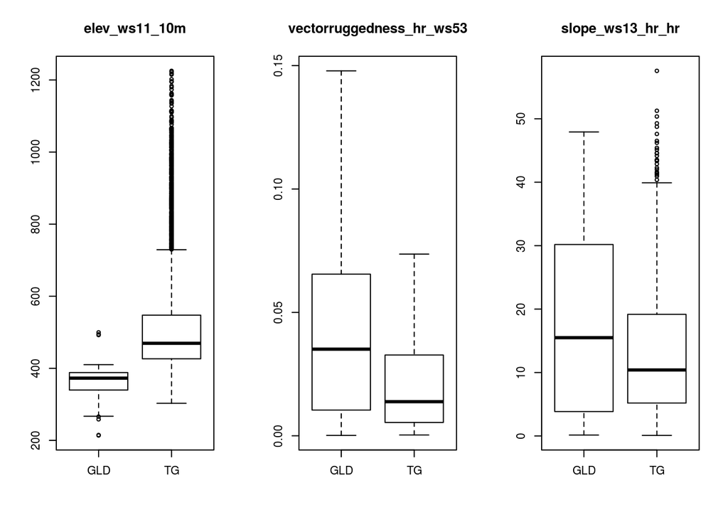